# First import the required libraries

```python
import pandas as pd
import numpy as np
import matplotlib.pyplot as plt
import seaborn as sns
```

**Importing dataset**

```python
df= pd.read_csv('Balaji Fast Food Sales.csv')
```

```python
df
```

|  | order_id | date | item_name | item_type | item_price | quantity | transaction_amount | transaction_type | received_by | time_of_sale |
| --- | --- | --- | --- | --- | --- | --- | --- | --- | --- | --- |
| 0 | 1 | 07-03-2022 | Aalopuri | Fastfood | 20 | 13 | 260 | NaN | Mr. | Night |
| 1 | 2 | 8/23/2022 | Vadapav | Fastfood | 20 | 15 | 300 | Cash | Mr. | Afternoon |
| 2 | 3 | 11/20/2022 | Vadapav | Fastfood | 20 | 1 | 20 | Cash | Mr. | Afternoon |
| 3 | 4 | 02-03-2023 | Sugarcane juice | Beverages | 25 | 6 | 150 | Online | Mr. | Night |
| 4 | 5 | 10-02-2022 | Sugarcane juice | Beverages | 25 | 8 | 200 | Online | Mr. | Evening |
| ... | ... | ... | ... | ... | ... | ... | ... | ... | ... | ... |
| 995 | 996 | 3/19/2023 | Frankie | Fastfood | 50 | 10 | 500 | NaN | Mrs. | Evening |
| 996 | 997 | 9/20/2022 | Sandwich | Fastfood | 60 | 7 | 420 | NaN | Mr. | Evening |
| 997 | 998 | 1/26/2023 | Sandwich | Fastfood | 60 | 13 | 780 | NaN | Mr. | Evening |
| 998 | 999 | 8/27/2022 | Panipuri | Fastfood | 20 | 5 | 100 | NaN | Mrs. | Afternoon |
| 999 | 1000 | 5/29/2022 | Aalopuri | Fastfood | 20 | 3 | 60 | Online | Mrs. | Midnight |

1000 rows × 10 columns

**Checking the size of dataset**

```python
df.shape
```

```
(1000, 10)
```

**Checking the basic info of dataset**

```python
df.info()
```

```
<class 'pandas.core.frame.DataFrame'>
RangeIndex: 1000 entries, 0 to 999
Data columns (total 10 columns):
 #   Column              Non-Null Count  Dtype
---  ------              --------------  -----
 0   order_id            1000 non-null   int64
 1   date                1000 non-null   object
 2   item_name           1000 non-null   object
 3   item_type           1000 non-null   object
 4   item_price          1000 non-null   int64
 5   quantity            1000 non-null   int64
 6   transaction_amount  1000 non-null   int64
 7   transaction_type    893 non-null    object
 8   received_by         1000 non-null   object
 9   time_of_sale        1000 non-null   object
dtypes: int64(4), object(6)
memory usage: 78.3+ KB
```

```python
df.describe()
```

|  | order_id | item_price | quantity | transaction_amount |
| --- | --- | --- | --- | --- |
| count | 1000.000000 | 1000.000000 | 1000.000000 | 1000.000000 |
| mean | 500.500000 | 33.315000 | 8.162000 | 275.230000 |
| std | 288.819436 | 14.921744 | 4.413075 | 204.402979 |
| min | 1.000000 | 20.000000 | 1.000000 | 20.000000 |
| 25% | 250.750000 | 20.000000 | 4.000000 | 120.000000 |
| 50% | 500.500000 | 25.000000 | 8.000000 | 240.000000 |
| 75% | 750.250000 | 50.000000 | 12.000000 | 360.000000 |
| max | 1000.000000 | 60.000000 | 15.000000 | 900.000000 |

**Finding out the Null Values in the data set and we found just (transaction_type) has Null values**

```python
df.isnull().sum()
```

```
order_id                0
date                    0
item_name               0
item_type               0
item_price              0
quantity                0
transaction_amount      0
transaction_type      107
received_by             0
time_of_sale            0
dtype: int64
```

**Resolving the issue of Null Values**

```python
df['transaction_type'].unique()
```

```
array([nan, 'Cash', 'Online'], dtype=object)
```

```python
df['transaction_type'].value_counts()
```

```
Cash      476
Online    417
Name: transaction_type, dtype: int64
```

**As we see above the number of both transactions, there are different ways to solve this problem but we will use the approach **that most values are used in place of Null Values****

```python
most_frequent_value = df['transaction_type'].mode()[0]
df['transaction_type'].fillna(most_frequent_value, inplace=True)
```

```python
df['transaction_type'].value_counts()
```

```
Cash      583
Online    417
Name: transaction_type, dtype: int64
```

**Sample is a method used to see the Random vaalues in the Data Set**

```python
df.sample(10)
```

|  | order_id | date | item_name | item_type | item_price | quantity | transaction_amount | transaction_type | received_by | time_of_sale |
| --- | --- | --- | --- | --- | --- | --- | --- | --- | --- | --- |
| 797 | 798 | 5/22/2022 | Frankie | Fastfood | 50 | 12 | 600 | Cash | Mr. | Night |
| 674 | 675 | 4/17/2022 | Sandwich | Fastfood | 60 | 12 | 720 | Cash | Mr. | Night |
| 965 | 966 | 3/19/2023 | Panipuri | Fastfood | 20 | 11 | 220 | Online | Mrs. | Morning |
| 122 | 123 | 06-09-2022 | Cold coffee | Beverages | 40 | 6 | 240 | Online | Mr. | Evening |
| 707 | 708 | 3/15/2023 | Sandwich | Fastfood | 60 | 5 | 300 | Cash | Mrs. | Midnight |
| 982 | 983 | 3/17/2023 | Cold coffee | Beverages | 40 | 10 | 400 | Cash | Mrs. | Night |
| 629 | 630 | 5/27/2022 | Frankie | Fastfood | 50 | 7 | 350 | Cash | Mrs. | Morning |
| 52 | 53 | 7/26/2022 | Aalopuri | Fastfood | 20 | 13 | 260 | Cash | Mr. | Afternoon |
| 779 | 780 | 11/27/2022 | Sugarcane juice | Beverages | 25 | 13 | 325 | Online | Mrs. | Afternoon |
| 624 | 625 | 6/17/2022 | Sandwich | Fastfood | 60 | 15 | 900 | Online | Mr. | Morning |

**And there was an other issue in dataset date was of object datatype so we converted it in date and time format**  
**You can see it using df.info() as above we did**

```python
df['date'] = pd.to_datetime(df['date'])
```

```python
df.info()
```

```
<class 'pandas.core.frame.DataFrame'>
RangeIndex: 1000 entries, 0 to 999
Data columns (total 10 columns):
 #   Column              Non-Null Count  Dtype
---  ------              --------------  -----
 0   order_id            1000 non-null   int64
 1   date                1000 non-null   datetime64[ns]
 2   item_name           1000 non-null   object
 3   item_type           1000 non-null   object
 4   item_price          1000 non-null   int64
 5   quantity            1000 non-null   int64
 6   transaction_amount  1000 non-null   int64
 7   transaction_type    1000 non-null   object
 8   received_by         1000 non-null   object
 9   time_of_sale        1000 non-null   object
dtypes: datetime64[ns](1), int64(4), object(5)
memory usage: 78.3+ KB
```

# Now Perform EDA

**We will solve according to the given problems**

***Analyzing sales trends over time.***

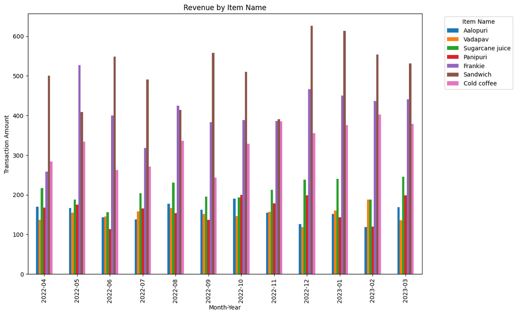

```python
df['Month_Year'] = df['date'].dt.to_period("M")

# Create a pivot table
pivot_table = pd.pivot_table(df, values='transaction_amount', index='Month_Year', columns='item_name')

# Plotting using Matplotlib
pivot_table.plot(kind='bar', y=df['item_name'].unique(), figsize=(12, 8), title='Revenue by Item Name')
plt.xlabel('Month-Year')
plt.ylabel('Transaction Amount')
plt.legend(title='Item Name', bbox_to_anchor=(1.05, 1), loc='upper left')  # Adjust legend position
plt.show()
```

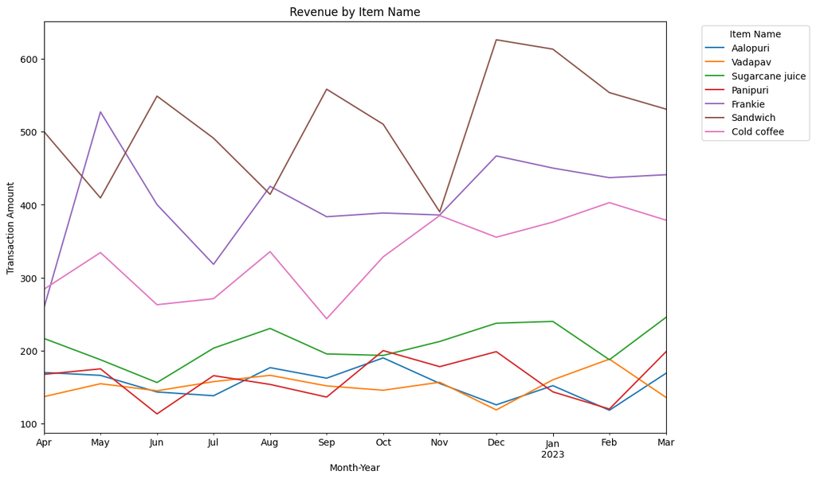

```python
df['Month_Year'] = df['date'].dt.to_period("M")

# Create a pivot table
pivot_table = pd.pivot_table(df, values='transaction_amount', index='Month_Year', columns='item_name')

# Plotting using Matplotlib
pivot_table.plot(kind='line', y=df['item_name'].unique(), figsize=(12, 8), title='Revenue by Item Name')
plt.xlabel('Month-Year')
plt.ylabel('Transaction Amount')
plt.legend(title='Item Name', bbox_to_anchor=(1.05, 1), loc='upper left')  # Adjust legend position
plt.show()
```

***Understanding customer preferences for different items.***

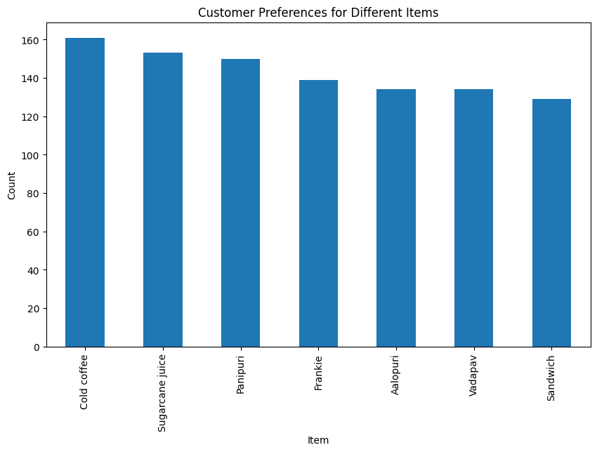

```python
# Assuming you have a column 'item' representing different items
item_preferences = df['item_name'].value_counts()

# Plotting
item_preferences.plot(kind='bar', figsize=(10, 6) )

plt.title('Customer Preferences for Different Items')
plt.xlabel('Item')
plt.ylabel('Count')
plt.show()
```

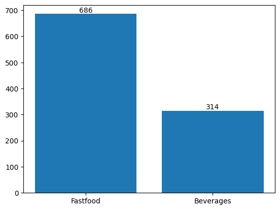

```python
preferences = df['item_type'].value_counts()

fig, ax = plt.subplots()
bars = ax.bar(preferences.index, preferences)

# Add values on top of the bars
for bar in bars:
    yval = bar.get_height()
    ax.text(bar.get_x() + bar.get_width()/2, yval, round(yval, 2), ha='center', va='bottom')


plt.show()
```

**Evaluating the impact of payment methods on revenue.**

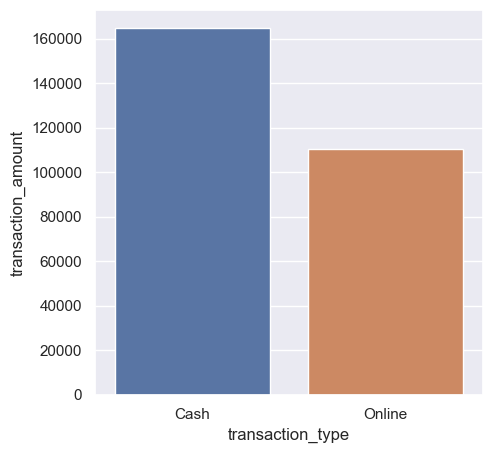

```python
#Check the number of orders according to the state , and will show First 10 states
state_orders=df.groupby(['transaction_type'], as_index=False)['transaction_amount'].sum().sort_values(by='transaction_amount' , ascending=False)

#set the width of graph otherwise state names overlap and reduce the readability
sns.set(rc={'figure.figsize':(5,5)})

sns.barplot(x='transaction_type' , y='transaction_amount' , data=state_orders)
```

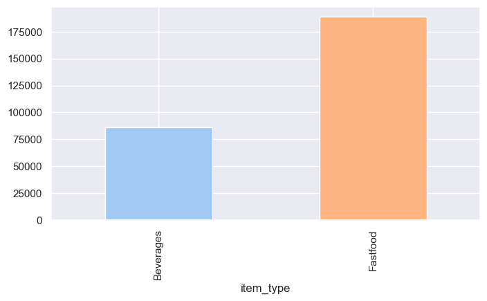

```python
plt.figure(figsize = (10,10))
palette = sns.color_palette("pastel", n_colors=5)
df.groupby('item_type')['transaction_amount'].sum().plot(kind='bar', figsize=(8,4), color=palette)
plt.show()
```

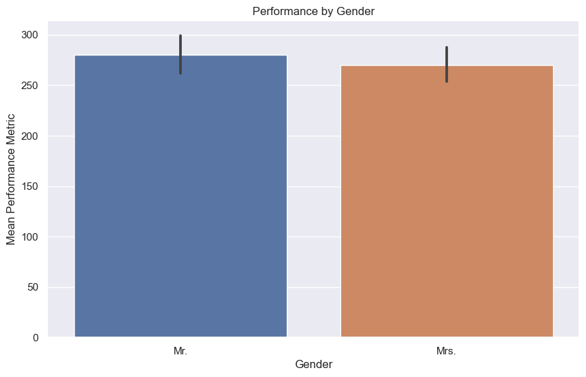

```python
plt.figure(figsize=(10, 6))
sns.barplot(x='received_by', y='transaction_amount', data=df, estimator='mean')
plt.title('Performance by Gender')
plt.xlabel('Gender')
plt.ylabel('Mean Performance Metric')
plt.show()
```

```python
df.columns
```

```
Index(['order_id', 'date', 'item_name', 'item_type', 'item_price', 'quantity',
       'transaction_amount', 'transaction_type', 'received_by', 'time_of_sale',
       'Month_Year'],
      dtype='object')
```

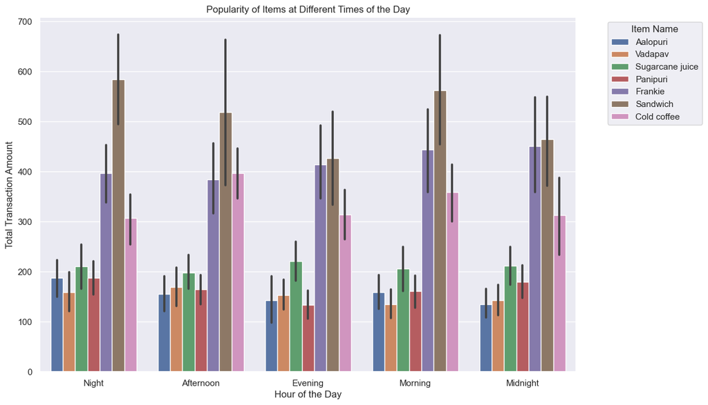

```python
plt.figure(figsize=(12, 8))
sns.barplot(x='time_of_sale', y='transaction_amount', hue='item_name', data=df)
plt.title('Popularity of Items at Different Times of the Day')
plt.xlabel('Hour of the Day')
plt.ylabel('Total Transaction Amount')
plt.legend(title='Item Name', bbox_to_anchor=(1.05, 1), loc='upper left')  # Adjust legend position
plt.show()
```

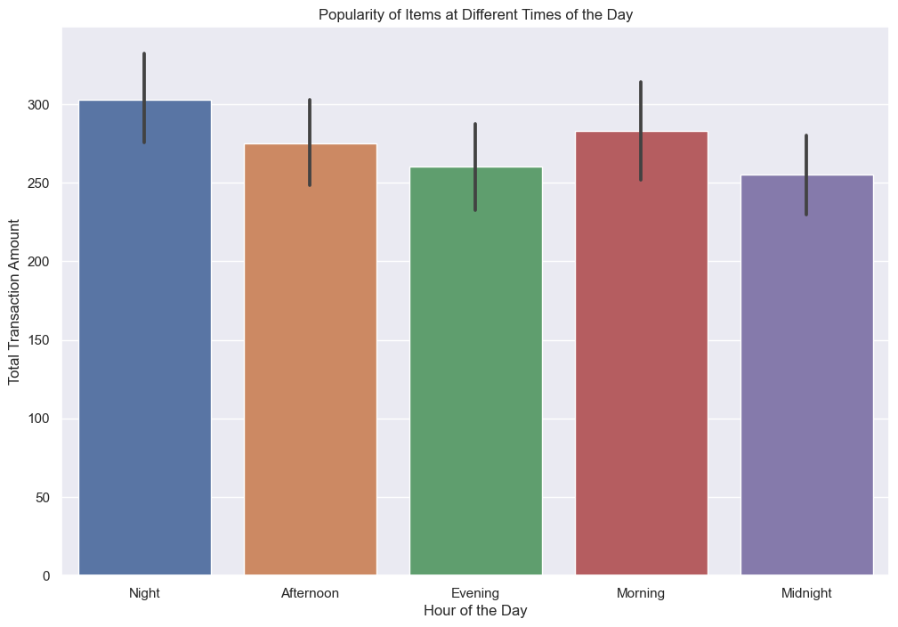

```python
plt.figure(figsize=(12, 8))
sns.barplot(x='time_of_sale', y='transaction_amount', data=df )
plt.title('Popularity of Items at Different Times of the Day')
plt.xlabel('Hour of the Day')
plt.ylabel('Total Transaction Amount')
plt.show()
```

# Report

**Customer preferences indicate a higher inclination towards Cold Coffee, Sugarcane Juice, and Pani Puri. This trend is evident when visualizing the data, which shows that fast food items are more popular and have higher sales compared to beverages.**

**Evaluating the impact of payment methods on revenue, it is observed that the most effective method for generating higher revenue is using cash rather than online payments.**

**Investigating the performance of staff members based on gender, it is evident that males exhibit a slightly higher performance in sales compared to females, although the difference is not significant.**